# Requetes_MongoDB_R

Trésor Djonga

06/02/2020

###Connexion à la base test.

```r
library(mongolite)
m = mongo(db = "test",
          collection = "restaurants")
```

```r
m$find(query = '{"name":"Bareburger"}',
       fields='{"_id":0,"adress.street":1,"borough":1}')
```

```
##      borough
## 1     Queens
## 2  Manhattan
## 3   Brooklyn
## 4     Queens
## 5  Manhattan
## 6  Manhattan
## 7     Queens
## 8     Queens
## 9   Brooklyn
## 10 Manhattan
## 11 Manhattan
## 12 Manhattan
```

```r
m$aggregate(pipeline = '[
    {"$group": {"_id": "$name", "NbRestos": {"$sum": 1}}},
    { "$sort": { "NbRestos": 1}},
    { "$limit": 3 }
]')
```

```
##                               _id NbRestos
## 1 Jade Seneca Oriental Restaurant        1
## 2                           Maman        1
## 3       St. Gambrinus Beer Shoppe        1
```

3.Lister les 10 restaurants les moins bien notés (note moyenne la plus haute).

```r
m$aggregate('[
    { "$unwind": "$grades" },
    { "$group": { "_id": "$name", "score": { "$avg": "$grades.score" }}},
    { "$sort": { "score": -1}},
    { "$limit": 10 }
]')
```

```
##                             _id score
## 1           Juice It Health Bar    75
## 2         Golden Dragon Cuisine    73
## 3       Chelsea'S Juice Factory    69
## 4           Palombo Pastry Shop    69
## 5                         Koyla    61
## 6            K & D Internet Inc    61
## 7              Ivory D O S  Inc    60
## 8           Ab Halal Restaurant    58
## 9     Wing Hing Chinese Cuisine    56
## 10 Kikka At Whole Foods Chelsea    56
```

4.Lister par quartier le nombre de restaurants, le score moyen et le pourcentage moyen d’évaluation A.

```r
#Calcul sur l'ensemble de la base
df1<-m$aggregate('[
    { "$unwind": "$grades" },
    { "$group": { "_id": "$borough", "NbRestos": {"$sum": 1}, "score_moyen": { "$avg": "$grades.score" }}}
]')

df1 <-data.frame("numq"=df1[,1],"NbRestos"=df1[,2], "score_moyen"=df1[,3])

#Comptage nombre restaurant évaluation A par quartier.
df2<-m$aggregate('[
    { "$match": { "grades.grade": "A" }},
    { "$group": { "_id": "$borough", "NbRestos_A": {"$sum": 1}}}
]')
df2 <-data.frame("numq"=df2[,1],"NbRestos_A"=df2[,2])

#Jointure de deux tables
df2<-merge(df2,df1,  by = "numq", all.x = TRUE)

#calcul pourcentage
df2$percentA<-(df2$NbRestos_A/df2$NbRestos)*100

#suppression colonne non utile
df2$NbRestos_A <- NULL

#Solution finale
print(df2)
```

```
##            numq NbRestos score_moyen percentA
## 1         Bronx     8706   11.036186 24.90237
## 2      Brooklyn    21963   11.447976 25.54296
## 3     Manhattan    38622   11.418151 24.80193
## 4       Missing       79    9.632911 63.29114
## 5        Queens    20877   11.634865 24.70182
## 6 Staten Island     3216   11.370958 27.23881
```

5.Afficher les restaurants sur une carte en mettant une couleur en fonction de la note moyenne des restaurants.

```r
library(leaflet)
library(tidyverse)
df = m$aggregate(
'[
    { "$project": {
         "borough": 1,"_id":0,
        "lng": { "$arrayElemAt": ["$address.coord", 0]},
        "lat": { "$arrayElemAt": ["$address.coord", 1]}
    }}
]')

df <-data.frame("numq"=df[,1],"lng"=df[,2], "lat"=df[,3])

df<-merge(df,df2,  by = "numq", all.x = TRUE)

pal = colorFactor("Accent", df$score_moyen)
leaflet(df) %>%
  addProviderTiles(providers$CartoDB.Positron) %>%
  setView(lng  = -73.9,
          lat  =  40.7,
          zoom =  10) %>%
  addCircles(lng = ~lng, lat = ~lat, color = ~pal(score_moyen)) %>%
  addLegend(pal = pal, values = ~score_moyen, opacity = 1,
            title = "Note moyenne")
```

[interactive chart not shown]

## Horodateurs parisien.

```r
#Connexion à la base mobiliers
library(mongolite)
h = mongo(db = "horodateurs",
          collection = "mobiliers")
```

1.Lister les informations du premier mobilier.

```r
first<-h$find(limit = 1)
print(first)
```

```
##               datasetid                                 recordid
## 1 horodateurs-mobiliers 698c75a21ba4f4c34e72f32ea1ecd94f9de8b88c
##   fields.tarifhor fields.alim fields.objectid               fields.adresse
## 1               4     SOLAIRE            4383 48 vis-à-vis RUE DE LISBONNE
##   fields.geo_point_2d fields.arrondt  fields.tarif fields.geo_shape.type
## 1 48.877490, 2.311395              8 4,00 E MIX 2U                 Point
##   fields.geo_shape.coordinates fields.zoneres fields.numhoro fields.modele
## 1          2.311395, 48.877490             8J       57080603          SAB3
##   fields.regime geometry.type geometry.coordinates
## 1           MIX         Point  2.311395, 48.877490
##            record_timestamp
## 1 2015-12-02T17:49:46+00:00
```

2.Donner le nombre de mobiliers.

```r
nbr_mob<-h$count()
print(nbr_mob)
```

```
## [1] 7810
```

3.Lister les informations de la première. transaction.

```r
#Connexion à la base transaction.
t = mongo(db = "horodateurs",
          collection = "transactions_small")
first<-t$find(limit = 1)
print("les informations de la première transaction")
```

```
## [1] "les informations de la première transaction"
```

```r
print(first)
```

```
##   horodateur     date horodateur  usager moyen de paiement montant carte
## 1   36590413 2014-07-16 14:51:09 Rotatif       Paris Carte           1.2
##   durÃ©e payÃ©e (h) dÃ©but stationnement   fin stationnement
## 1                 1  2014-07-16 14:51:09 2014-07-16 15:51:09
```

4.Donner le nombre de transactions.

```r
nbr_tran<-t$count()
print(nbr_tran)
```

```
## [1] 244480
```

5.Lister les informations du mobilier 1234 (cf objectid).

```r
obj<-h$find(query = '{"fields.objectid":1234}')
print(obj)
```

```
##               datasetid                                 recordid
## 1 horodateurs-mobiliers 9ee0a713bde77e340e999ebea2408894f8a9a2fa
##   fields.tarifhor fields.alim fields.objectid   fields.adresse
## 1             2.4     SOLAIRE            1234 15 RUE CERNUSCHI
##   fields.geo_point_2d fields.arrondt  fields.tarif fields.geo_shape.type
## 1 48.886669, 2.307837             17 2,40 E MIX 2U                 Point
##   fields.geo_shape.coordinates fields.zoneres fields.numhoro fields.modele
## 1          2.307837, 48.886669            17L       16530203          SAB3
##   fields.regime geometry.type geometry.coordinates
## 1           MIX         Point  2.307837, 48.886669
##            record_timestamp
## 1 2015-12-02T17:49:46+00:00
```

6.Donner le nombre de mobiliers pour chaque arrondissement.

```r
arr<-h$aggregate(pipeline = '[
    {"$group": {"_id": "$fields.arrondt", "NbMobiliers": {"$sum": 1}}}
]')
print(arr)
```

```
##    _id NbMobiliers
## 1   19         473
## 2   13         514
## 3    3         133
## 4    6         174
## 5    9         227
## 6    2          67
## 7   17         698
## 8   16         959
## 9    5         267
## 10   8         376
## 11  10         197
## 12  11         440
## 13   4         135
## 14  14         448
## 15   7         361
## 16   1          87
## 17  20         492
## 18  18         494
## 19  15         810
## 20  12         458
```

7.Croiser le régime (regime) et les arrondissements pour voir s’il y a des différences notables (idéalement en réalisant un graphique avec ggplot).

```r
library("ggplot2")

dd<-h$find(fields = '{ "_id": 0,"fields.arrondt": 1, "fields.regime": 1}')


df <-data.frame("Arrondissement"=dd$fields[,1],"Regime"=dd$fields[,2])

print(table(df$Arrondissement,df$Regime))
```

```
##
##      MIX ROT
##   1   63  24
##   2   49  18
##   3   82  51
##   4  118  17
##   5  241  26
##   6  141  33
##   7  337  24
##   8  293  83
##   9  157  70
##   10 159  38
##   11 339 101
##   12 389  69
##   13 448  66
##   14 409  39
##   15 720  90
##   16 885  74
##   17 619  79
##   18 455  39
##   19 418  55
##   20 456  36
```

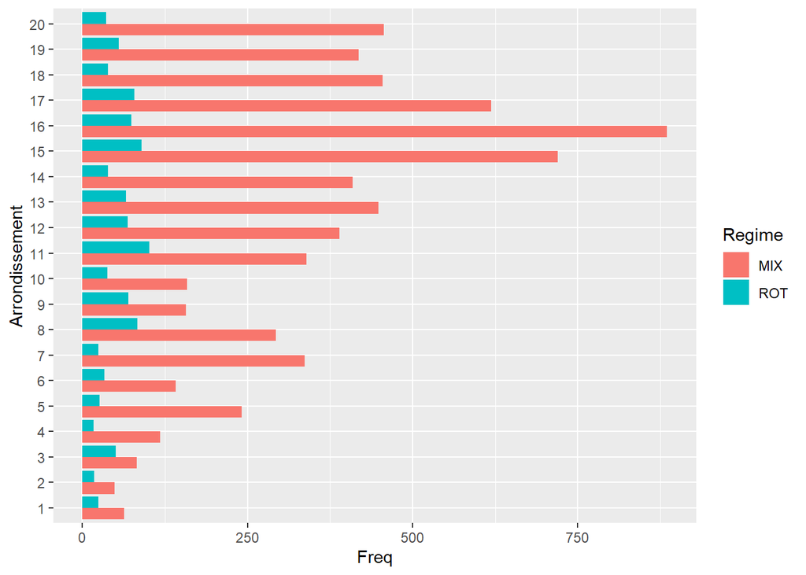

```r
ggplot(as.data.frame(table(df)), aes(x=Arrondissement, y = Freq, fill=Regime))  + geom_bar(stat = "identity",
    position = "dodge") + coord_flip()
```

8.Donner la distribution des montants payés (montant carte) et des durées payées (durée payée (h)) des transactions.

```r
#Distribution des montant payés

DM<-t$aggregate(pipeline = '[
    {"$group": {"_id": "$montant carte", "DistrMontant": {"$sum": 1}}}
]')

print(head(DM))
```

```
##    _id DistrMontant
## 1 0.31            3
## 2 0.51            7
## 3 3.60         8659
## 4 1.29            1
## 5 0.61            3
## 6 3.21            2
```

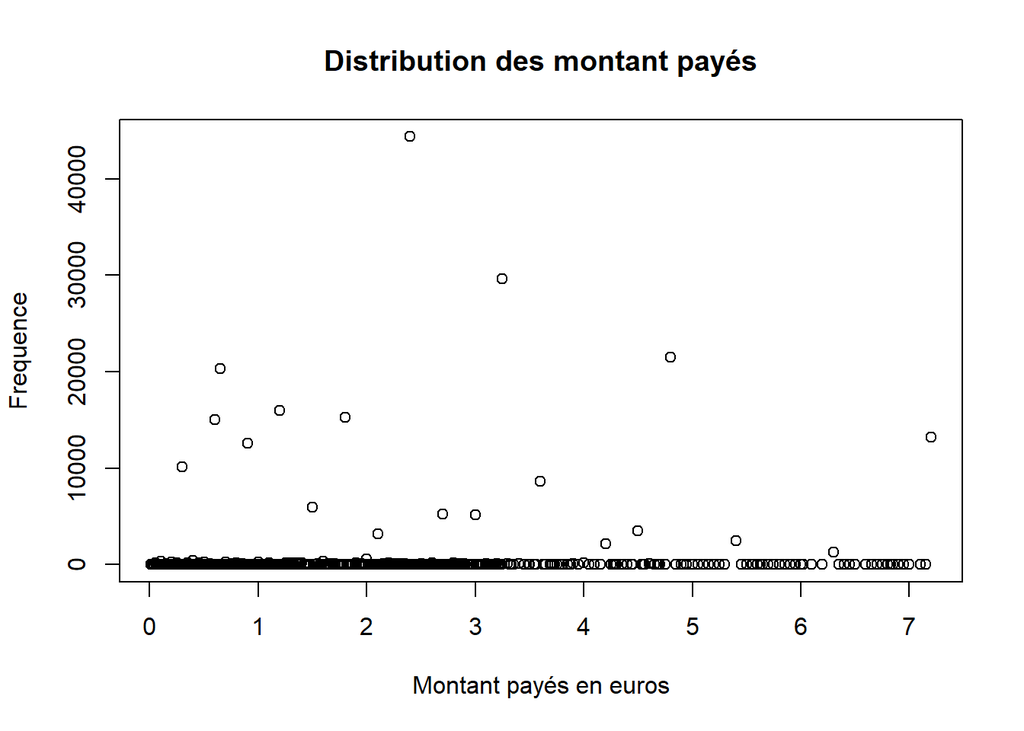

```r
print(plot(DM$`_id`,DM$DistrMontant,xlab="Montant payés en euros", ylab="Frequence", main="Distribution des montant payés"))
```

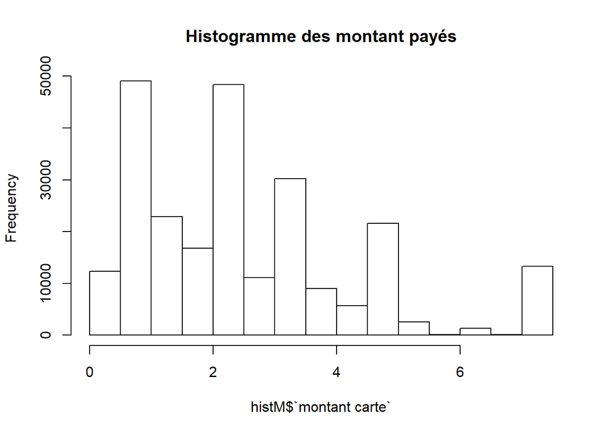

```r
histM<-t$find(fields = '{ "_id": 0,"montant carte": 1}')

hist(histM$`montant carte`,main="Histogramme des montant payés")
```

```r
#--------------------------------------------------

#Distribution durées payées

DD<-t$aggregate(pipeline = '[
    {"$group": {"_id": "$durée payée (h)", "DistrPayes": {"$sum": 1}}}
]')

print(head(DD))
```

```
##     _id DistrPayes
## 1  0.20          3
## 2  0.13        106
## 3  9.07          1
## 4  9.69          2
## 5 49.54          1
## 6  0.87          1
```

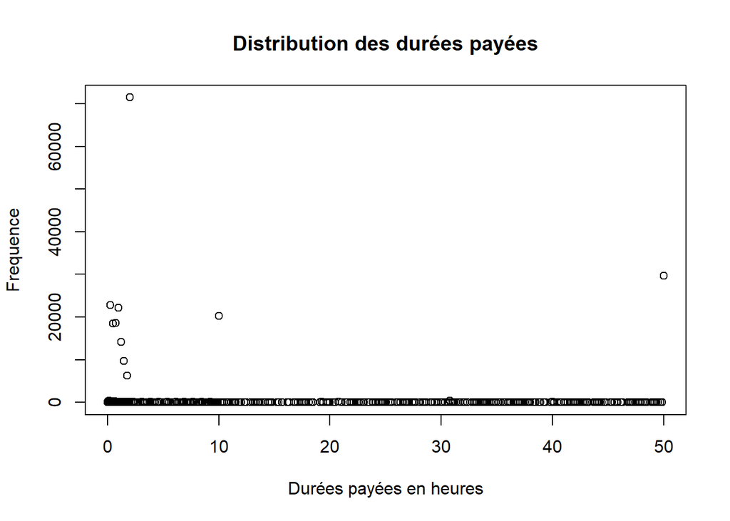

```r
print(plot(DD$`_id`,DD$DistrPayes,xlab="Durées payées en heures", ylab="Frequence", main="Distribution des durées payées"))
```

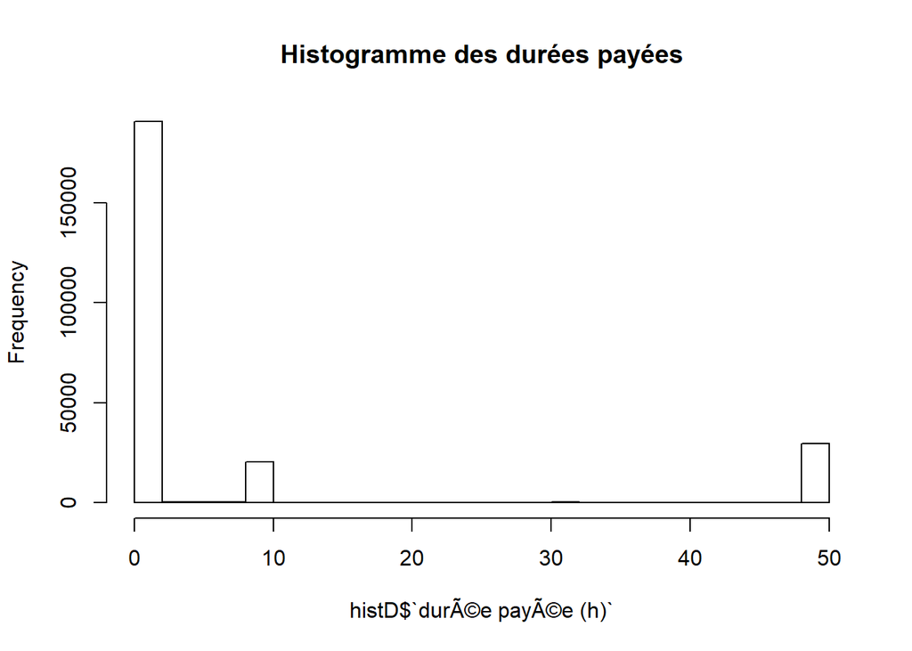

```r
histD<-t$find(fields = '{ "_id": 0,"durée payée (h)": 1}')

hist(histD$`durÃ©e payÃ©e (h)`,main="Histogramme des durées payées")
```

```r
h$aggregate('[
  {"$group": { "_id": "$fields.arrondt", "nbTrans": { "$sum": 1}}},
  { "$lookup": {
    "from": "transactions_small",
    "localField": "numhoro",
    "foreignField": "horodateur",
    "as": "info"
  }},
  {"$project": { "info": 0}}
]')
```

```
##    _id nbTrans
## 1   19     473
## 2   13     514
## 3    3     133
## 4    6     174
## 5    9     227
## 6    2      67
## 7   17     698
## 8   16     959
## 9    5     267
## 10   8     376
## 11  10     197
## 12  11     440
## 13   4     135
## 14  14     448
## 15   7     361
## 16   1      87
## 17  20     492
## 18  18     494
## 19  15     810
## 20  12     458
```

10.Représenter chaque mobilier sur la carte de Paris, en ajoutant une couleur en fonction du nombre de transactions réalisées durant l’année.

```r
#Extraction des coordonnées des horodateurs
mobi.coord = h$aggregate(
'[
    { "$project": {

        "_id":0, "fields.numhoro": 1,
        "lng": { "$arrayElemAt": ["$fields.geo_point_2d", 0]},
        "lat": { "$arrayElemAt": ["$fields.geo_point_2d", 1]}
    }}
]')

df1 <-data.frame("numhoro"=mobi.coord[,1],"lng"=mobi.coord[,2], "lat"=mobi.coord[,3])


#Nombre des transactions par horodataire.
df2<- t$aggregate('[ { "$group": { "_id": "$horodateur", "nb_trans": { "$sum": 1}}}]')

df2 <-data.frame("numhoro"=df2[,1],"nb_trans"=df2[,2])

df2<-merge(df2,df1,  by = "numhoro", all.x = TRUE)
```

```r
library(leaflet)
pal = colorFactor("Accent", df2$nb_trans)
leaflet(df2) %>%
  addProviderTiles(providers$CartoDB.Positron) %>%
  addCircles(lng = ~lng, lat = ~lat, color = ~pal(nb_trans)) %>%
  addLegend(pal = pal, values = ~nb_trans, opacity = 1,
            title = "Nombre des transactions")
```

[interactive chart not shown]